# Examen2-R

Author

Daniela Prado Vargas

Carga paquetes y definir paleta para gráficos

```r
library(tidyverse)
paleta <- c("#FEEA08", "#203667", "#2957A4", "#9DD5E4", "#9A9899", "#6AB04A")
```

## 1. Abrir tabla

```r
moras <- read.table("C:/Users/danie/OneDrive/Escritorio/examen2/moras.txt",
                       header = TRUE,
                       sep = ",",
                       stringsAsFactors = FALSE)
```

## 2. Resumen de las variables numéricas

```r
moras$SALARIO <- as.numeric(gsub(",", ".", moras$SALARIO))
resumen <- summary(moras[sapply(moras, is.numeric)])
resumen
```

```
 IDENTIFICACION    SALARIO              EDAD
 Min.   :   1   Min.   :      10   Min.   :14.00
 1st Qu.:1251   1st Qu.:  297429   1st Qu.:31.00
 Median :2500   Median :  408495   Median :40.00
 Mean   :2500   Mean   :  657534   Mean   :41.91
 3rd Qu.:3750   3rd Qu.:  700000   3rd Qu.:52.00
 Max.   :5000   Max.   :16858742   Max.   :99.00
                NA's   :3          NA's   :3
```

## 3. Identificar valores atípicos

```r
moras <- moras %>%
  mutate(
    Z_Salario = (SALARIO - mean(SALARIO, na.rm = TRUE)) / sd(SALARIO, na.rm = TRUE),
    Outlier_Salario = ifelse(abs(Z_Salario) > 1.96, "Sí", "No"),

    Z_Edad = (EDAD - mean(EDAD, na.rm = TRUE)) / sd(EDAD, na.rm = TRUE),
    Outlier_Edad = ifelse(abs(Z_Edad) > 1.96, "Sí", "No")
  )
```

## 4. Detección de valores faltantes por colummna

```r
moras$TIPO_ASEGURAMIENTO <- na_if(trimws(moras$TIPO_ASEGURAMIENTO), "")
#De excel se detectó que aquí habían NA y al hacer el cálculo de porcentajes salía cero. Al revisar de forma manual me di cuenta que había como un "espacio", por lo que R no lo tomaba como NA.
moras %>%
  summarise(across(everything(), ~mean(is.na(.)) * 100))
```

```
  IDENTIFICACION SEXO SALARIO TIPO_ASEGURAMIENTO SECTOR INDICADOR_ACTIVO
1              0    0    0.06               0.04      0                0
  INDICADOR.EXTRANJERO INDICADOR_MOROSO EDAD Z_Salario Outlier_Salario Z_Edad
1                    0                0 0.06      0.06            0.06   0.06
  Outlier_Edad
1         0.06
```

## 5. Imputación de valores faltates

```r
conteo <- moras %>%
  filter(!is.na(TIPO_ASEGURAMIENTO)) %>%
  count(TIPO_ASEGURAMIENTO) %>%
  arrange(desc(n))

moda_tipo <- conteo$TIPO_ASEGURAMIENTO[1]

moras <- moras %>%
  mutate(
    SALARIO = ifelse(is.na(SALARIO), mean(SALARIO, na.rm = TRUE), SALARIO),
    EDAD = ifelse(is.na(EDAD), mean(EDAD, na.rm = TRUE), EDAD),
    TIPO_ASEGURAMIENTO = ifelse(is.na(TIPO_ASEGURAMIENTO), moda_tipo, TIPO_ASEGURAMIENTO)
    )
```

## 6. Gráficos de cantidad de individuos por cada categoría

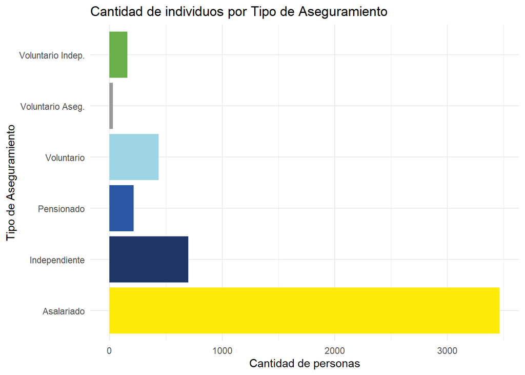

```r
moras <- moras %>%
  mutate(TIPO_ASEG_ABREV = case_when(
    TIPO_ASEGURAMIENTO == "TRABAJADOR INDEPENDIENTE" ~ "Independiente",
    TIPO_ASEGURAMIENTO == "PENSIONADOS EN SU PROPIO SISTEMA" ~ "Pensionado",
    TIPO_ASEGURAMIENTO == "ASALARIADO" ~ "Asalariado",
    TIPO_ASEGURAMIENTO == "CONVENIOS ESPECIALES DE ASEGURADOS VOLUNTARIOS" ~ "Voluntario Aseg.",
    TIPO_ASEGURAMIENTO == "CONVENIOS ESPECIALES DE TRABAJADORES INDEPENDIENTES" ~ "Voluntario Indep.",
    TIPO_ASEGURAMIENTO == "ASEGURADO VOLUNTARIO" ~ "Voluntario",
    TRUE ~ as.character(TIPO_ASEGURAMIENTO)
  ))

# Tipo de Aseguramiento
ggplot(moras, aes(x = TIPO_ASEG_ABREV)) +
  geom_bar(fill = paleta[1:6]) +
  labs(title = "Cantidad de individuos por Tipo de Aseguramiento",
       x = "Tipo de Aseguramiento",
       y = "Cantidad de personas") +
  theme_minimal() +
  coord_flip()
```

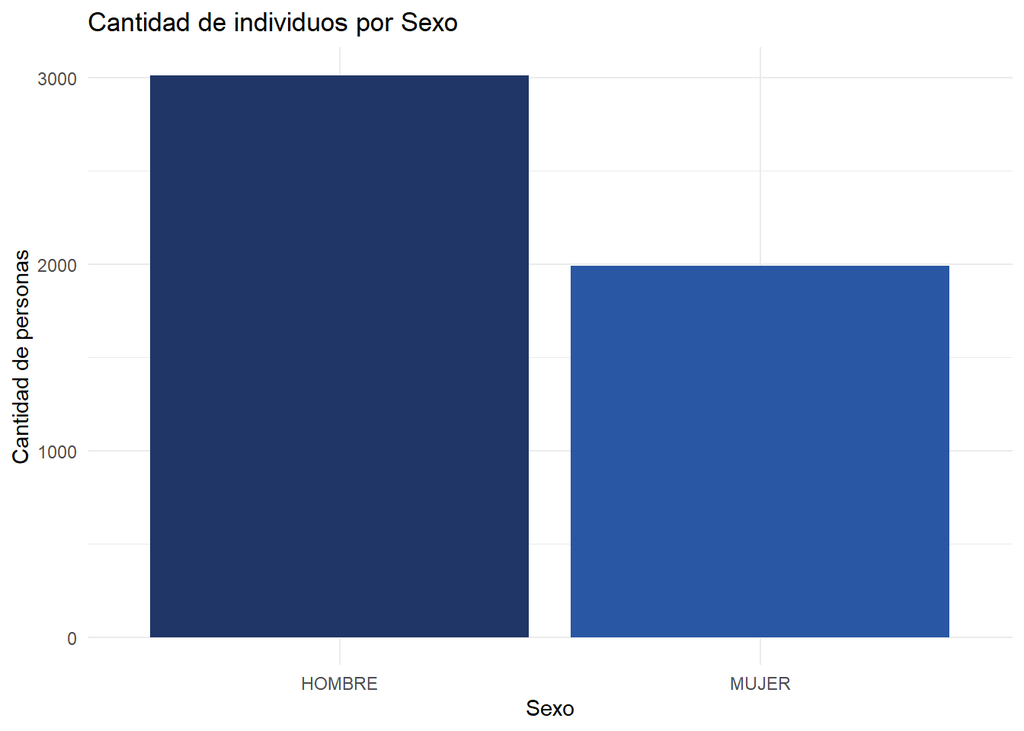

```r
# Sexo
ggplot(moras, aes(x = SEXO)) +
  geom_bar(fill = paleta[2:3]) +
  labs(title = "Cantidad de individuos por Sexo",
       x = "Sexo",
       y = "Cantidad de personas") +
  theme_minimal()
```

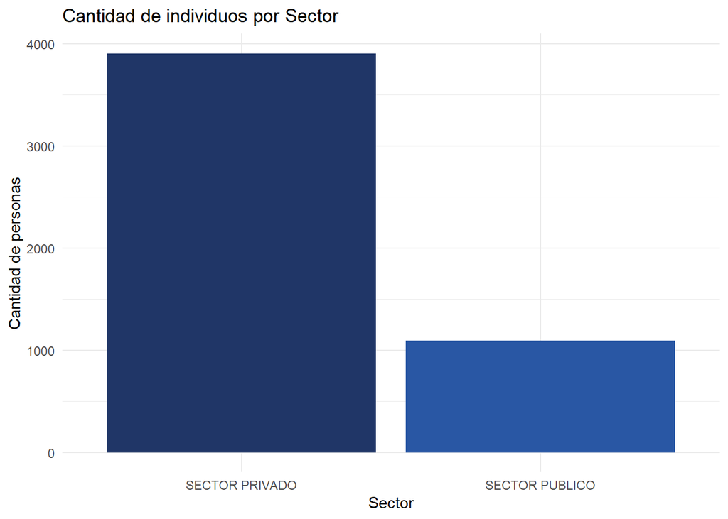

```r
# Sector
ggplot(moras, aes(x = SECTOR)) +
  geom_bar(fill = paleta[2:3]) +
  labs(title = "Cantidad de individuos por Sector",
       x = "Sector",
       y = "Cantidad de personas") +
  theme_minimal()
```

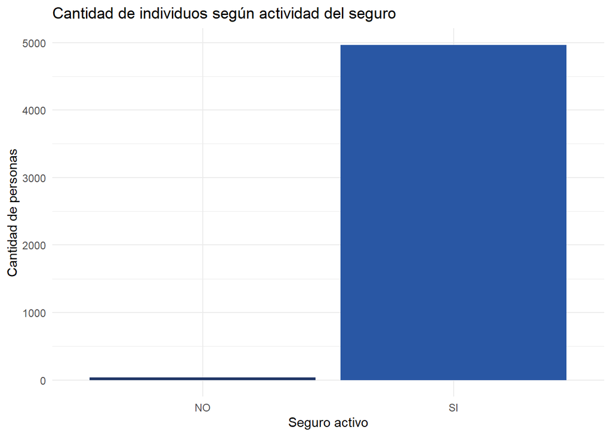

```r
# Activo seguro
ggplot(moras, aes(x = INDICADOR_ACTIVO)) +
  geom_bar(fill = paleta[2:3]) +
  labs(title = "Cantidad de individuos según actividad del seguro",
       x = "Seguro activo",
       y = "Cantidad de personas") +
  theme_minimal()
```

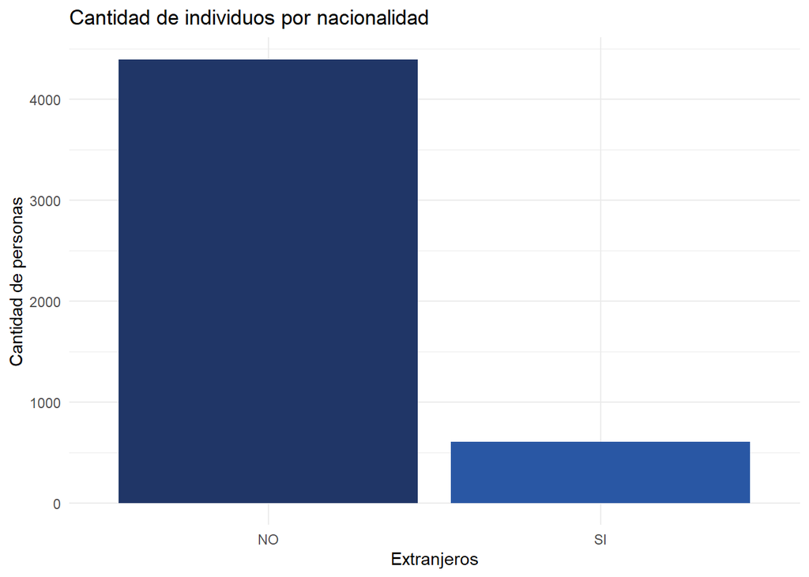

```r
# Extranjeros
ggplot(moras, aes(x = INDICADOR.EXTRANJERO)) +
  geom_bar(fill = paleta[2:3]) +
  labs(title = "Cantidad de individuos por nacionalidad",
       x = "Extranjeros",
       y = "Cantidad de personas") +
  theme_minimal()
```

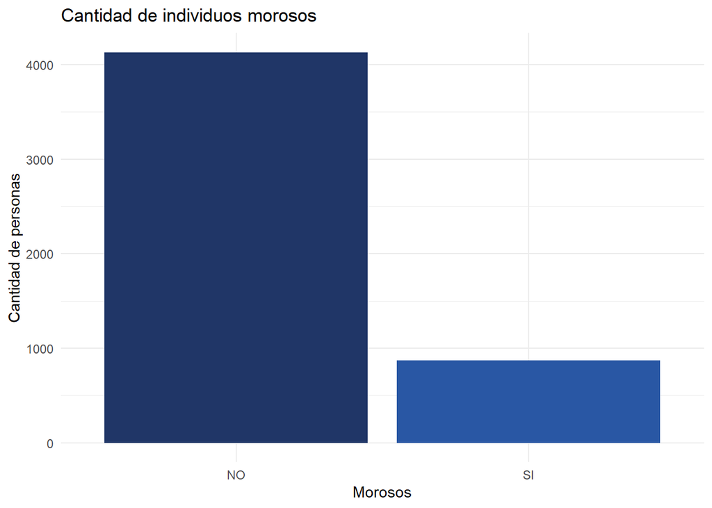

```r
#Morosos
ggplot(moras, aes(x = INDICADOR_MOROSO)) +
  geom_bar(fill = paleta[2:3]) +
  labs(title = "Cantidad de individuos morosos",
       x = "Morosos",
       y = "Cantidad de personas") +
  theme_minimal()
```

Análisis de los gráficos(mismo que en excel):

Sexo: El gráfico muestra la distribución de las personas según su sexo. Se observa que hay aproximadamente 3.000 hombres y 2.000 mujeres en el conjunto de datos.

Sector: En el gráfico se observa la distribución de la población según el sector laboral. La mayoría de las personas pertenecen al sector privado, con un poco menos de 4,000 individuos, mientras que el sector público cuenta con poco más de 1,000 personas. Esto indica que el empleo se concentra principalmente en el sector privado, siendo el sector público significativamente menor dentro de la muestra.

Nacionaliadad: En el gráfico se observa la distribución de la población según su nacionalidad. La gran mayoría de las personas son nacionales, con casi 4,500 individuos, mientras que las personas extranjeras representan una minoría, con un poco más de 500. Esto indica que la población está predominantemente compuesta por nacionales.

Morosos: En el gráfico se observa la distribución de la población según su estado de morosidad. La mayoría de las personas, con más de 4,000 individuos, no presentan morosidad, mientras que menos de 1,000 personas se encuentran morosas. Esto indica que la mayor parte de la población mantiene sus obligaciones al día, y solo una minoría presenta atrasos o deudas pendientes.

## 7. Porcentaje de morosos por clase

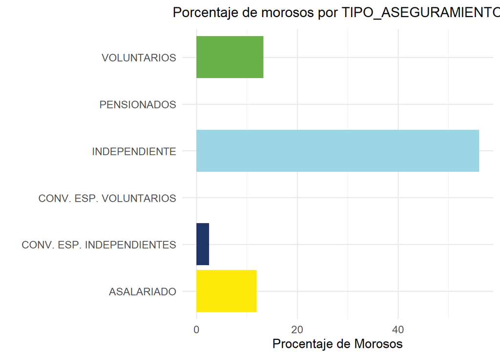

```r
resumen_morosos <- function(df, variable) {
  df %>%
    group_by(.data[[variable]]) %>%
    summarise(
      TOTAL = n(),
      MOROSOS = sum(INDICADOR_MOROSO == "SI"),
      PORCENTAJE = round((MOROSOS / TOTAL) * 100, 2)
    ) %>%
    rename(CATEGORIA = .data[[variable]])
}

grafico_morosos <- function(df, variable) {
  datos <- resumen_morosos(df, variable)

  if(variable == "TIPO_ASEGURAMIENTO") {
    abrev <- c(
      "ASALARIADO" = "ASALARIADO",
      "PENSIONADOS EN SU PROPIO SISTEMA" = "PENSIONADOS",
      "ASEGURADO VOLUNTARIO" = "VOLUNTARIOS",
      "TRABAJADOR INDEPENDIENTE" = "INDEPENDIENTE",
      "CONVENIOS ESPECIALES DE TRABAJADORES INDEPENDIENTES" = "CONV. ESP. INDEPENDIENTES",
      "CONVENIOS ESPECIALES DE ASEGURADOS VOLUNTARIOS" = "CONV. ESP. VOLUNTARIOS"
    )
    datos$CATEGORIA <- abrev[datos$CATEGORIA]
  }

  ggplot(datos, aes(x = CATEGORIA, y = PORCENTAJE, fill = CATEGORIA)) +
    geom_col() +
    coord_flip() +
    scale_fill_manual(values = paleta) +
    theme_minimal(base_size = 13) +
    theme(
      legend.position = "none",
      plot.title = element_text(size = 14, hjust = 0.5, margin = margin(b = 10))
    ) +
    labs(title = paste("Porcentaje de morosos por", variable),
         x = "",
         y = "Procentaje de Morosos")
}

grafico_morosos(moras, "TIPO_ASEGURAMIENTO")
```

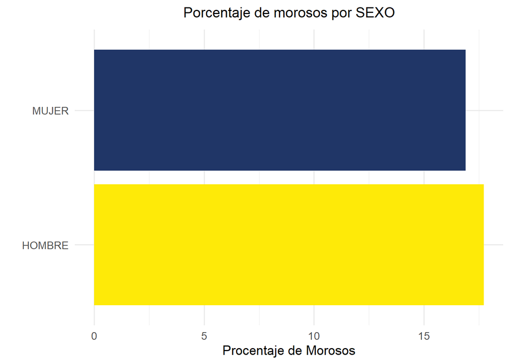

```r
grafico_morosos(moras, "SEXO")
```

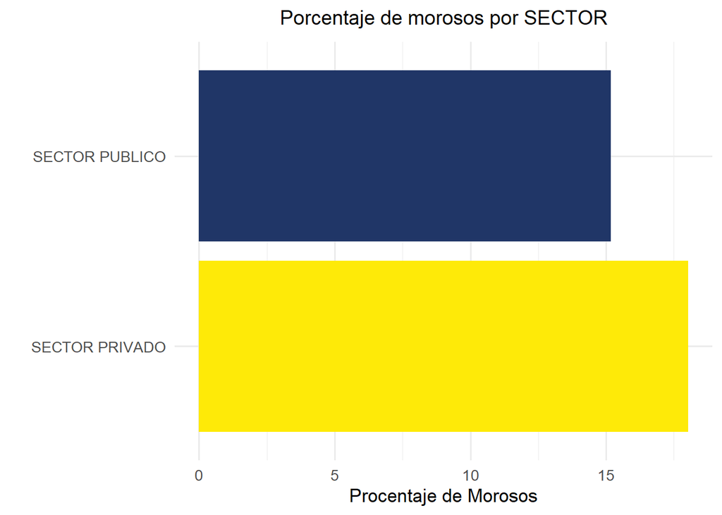

```r
grafico_morosos(moras, "SECTOR")
```

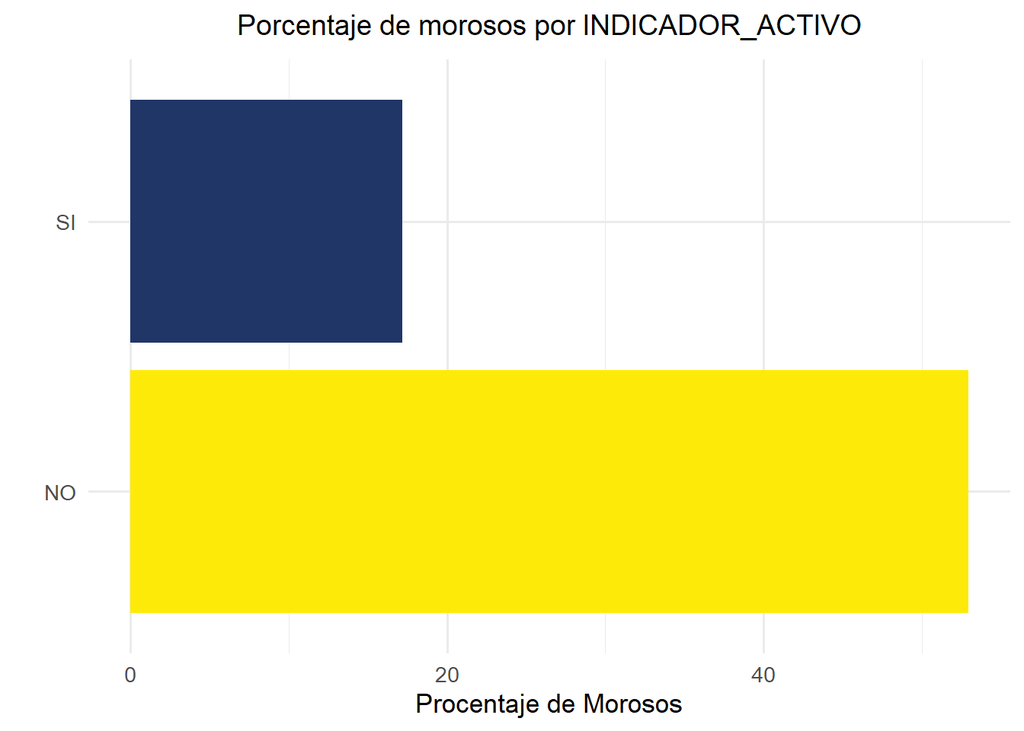

```r
grafico_morosos(moras, "INDICADOR_ACTIVO")
```

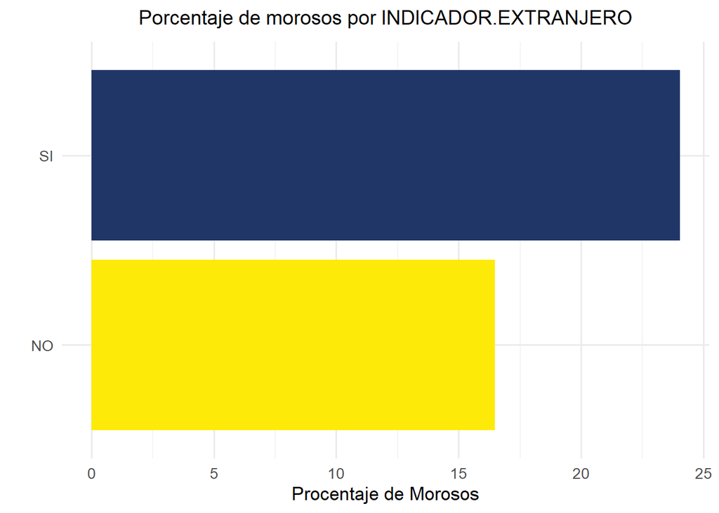

```r
grafico_morosos(moras, "INDICADOR.EXTRANJERO")
```

Análisis de los gráficos:

Tipo de aseguramiento: En el gráfico del porcentaje de morosos por tipo de aseguramiento se observa que los convenios especiales de asegurados voluntarios y los pensionados en su propio sistema presentan un 0% de morosidad, indicando que ninguna persona en estas categorías se encuentra morosa. Por otro lado, los trabajadores independientes muestran el porcentaje más alto de morosidad, con un 56%, mientras que los asegurados voluntarios tienen un 13%. Esto indica que la morosidad se concentra principalmente entre los trabajadores independientes, siendo mucho menor en las demás categorías.

Sexo: En el gráfico se observa el porcentaje de morosos según el sexo. Menos del 17% de las mujeres presentan morosidad, mientras que casi un 18% de los hombres se encuentran en esta situación. Esto indica que la proporción de morosos es ligeramente mayor entre los hombres, aunque la diferencia con respecto a las mujeres es mínima.

Sector: En el gráfico del porcentaje de morosos por sector se observa que el 18% de las personas en el sector privado son morosas, mientras que en el sector público la proporción es menor, con un 15%. Esto indica que, aunque la morosidad existe en ambos sectores, es ligeramente más alta en el sector privado.

Indicador activo: En el gráfico que muestra la morosidad según la activación del seguro, se observa que el 17% de las personas con el seguro activo presentan morosidad, mientras que el 52% de quienes no tienen el seguro activo son morosos. Esto indica que, en esta muestra, la morosidad es mayor entre quienes no tienen activo el seguro, mientras que quienes sí lo tienen activo presentan un porcentaje relativamente bajo de morosidad.

Extranjero: En el gráfico que muestra la morosidad según la nacionalidad, se observa que entre las personas extranjeras, el 24% son morosos, mientras que entre las personas nacionales, la proporción de morosos es menor, con un 16%. Esto indica que la morosidad es más alta entre los extranjeros que entre los nacionales en esta muestra.

## 8. Morosos para variables numéricas

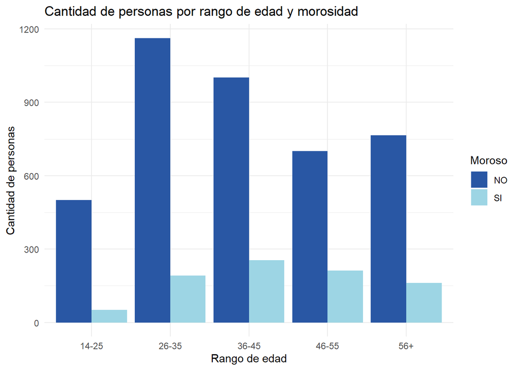

```r
moras <- moras %>%
  mutate(
    EDAD_RANGO = case_when(
      EDAD <= 25 ~ "14-25",
      EDAD <= 35 ~ "26-35",
      EDAD <= 45 ~ "36-45",
      EDAD <= 55 ~ "46-55",
      TRUE ~ "56+"
    ),
    EDAD_RANGO = factor(EDAD_RANGO, levels = c("14-25","26-35","36-45","46-55","56+"))
  )

moras <- moras %>%
  mutate(
    SALARIO_RANGO = case_when(
      SALARIO <= 500000 ~ "0-500k",
      SALARIO <= 1000000 ~ "500k-1M",
      SALARIO <= 5000000 ~ "1M-5M",
      SALARIO <= 10000000 ~ "5M-10M",
      TRUE ~ "10M+"
    ),
    SALARIO_RANGO = factor(SALARIO_RANGO, levels = c("0-500k","500k-1M","1M-5M","5M-10M","10M+"))
  )

# Gráfico de Edad
ggplot(moras, aes(x = EDAD_RANGO, fill = INDICADOR_MOROSO)) +
  geom_bar(position = "dodge") +
  scale_fill_manual(values = paleta[3:4]) +
  labs(title = "Cantidad de personas por rango de edad y morosidad",
       x = "Rango de edad",
       y = "Cantidad de personas",
       fill = "Moroso") +
  theme_minimal()
```

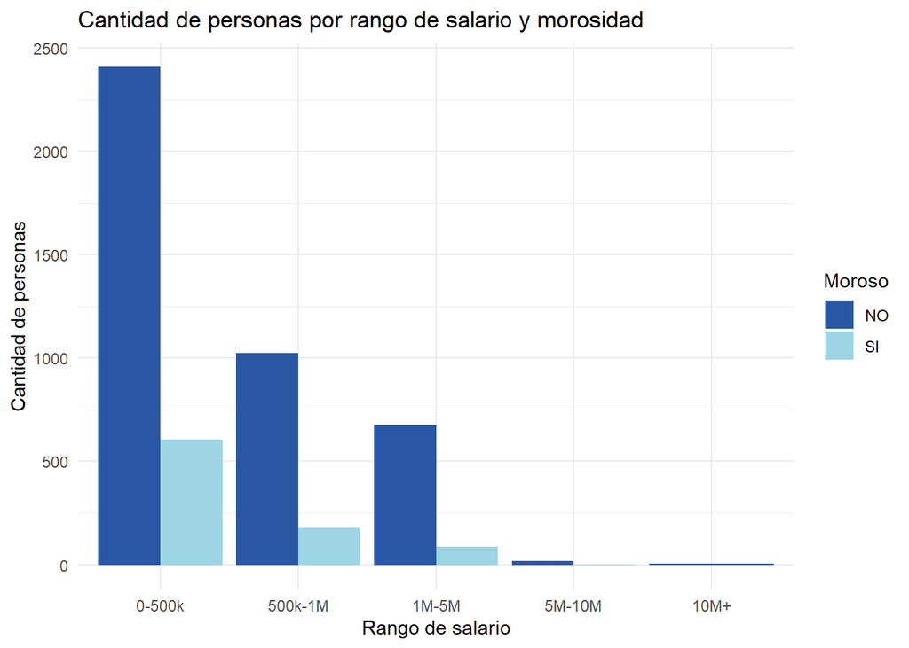

```r
# Gráfico de Salario
ggplot(moras, aes(x = SALARIO_RANGO, fill = INDICADOR_MOROSO)) +
  geom_bar(position = "dodge") +
  scale_fill_manual(values = paleta[3:4]) +
  labs(title = "Cantidad de personas por rango de salario y morosidad",
       x = "Rango de salario",
       y = "Cantidad de personas",
       fill = "Moroso") +
  theme_minimal()
```

Análisis de gráficos:

Salario y morosidad: En el gráfico que muestra la cantidad de morosos por rango de salario se observa que la mayor cantidad de personas morosas se concentra en el rango más bajo, de 0 a 500.000, con 605 morosos. En los rangos intermedios, 500.001-1.000.000 y 1.000.001-5.000.000, hay 178 y 86 morosos respectivamente, mostrando que la morosidad disminuye a medida que aumenta el salario. Finalmente, en el rango más alto, 5.000.001-16.858.742, hay solo 1 moroso, lo que indica que la morosidad es prácticamente nula entre los salarios más altos. Esto refleja que la morosidad está fuertemente asociada con los ingresos más bajos.

## 10. Arbol

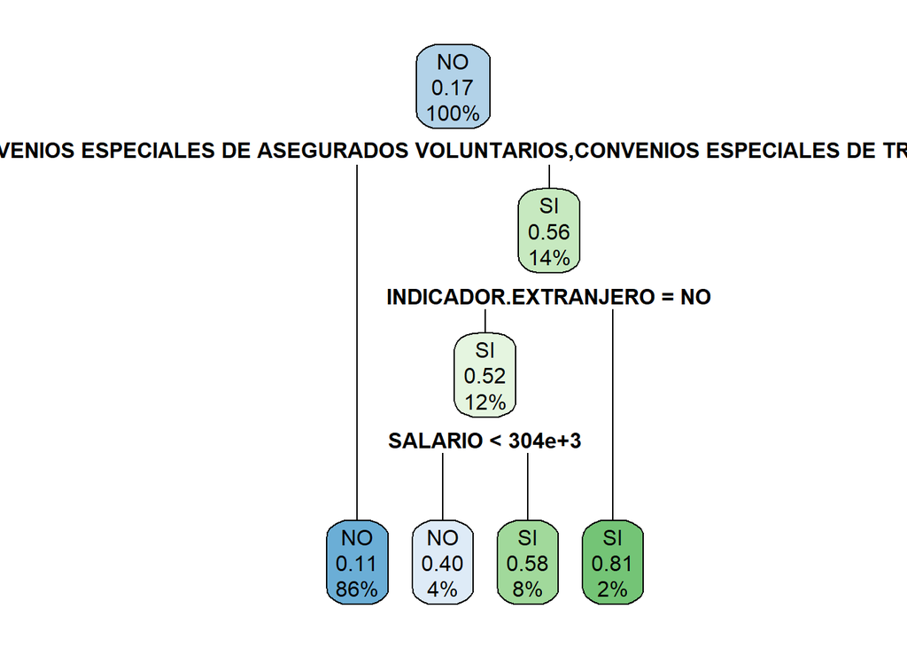

```r
library(rpart)
library(rpart.plot)
arbol <- rpart(INDICADOR_MOROSO ~ ., data = moras)

rpart.plot(arbol)
```

El árbol nos muestra que la variable que más influencia tiene sobre la morosidad es el tipo de aseguramiento. Las personas con aseguramiento tradicional (asalariados, voluntarios y pensionados) tienden a ser menos morosas. En cambio, dentro del grupo que no pertenece a estas categorías, ser extranjero aparece como el factor más relevante: los extranjeros presentan los niveles más altos de morosidad en toda la base. Por otro lado, entre quienes no son extranjeros, el salario marca otra división importante: quienes ganan más de ₡304 000 muestran un riesgo mayor de morosidad, probablemente porque tienen más compromisos financieros. En resumen, el modelo indica que las características laborales, la condición de extranjero y el nivel de ingresos son claves para identificar los perfiles con mayor probabilidad de ser morosos, ofreciendo así información útil para tomar decisiones más informadas.